# Correction Fiche 1 : Introduction à R

Septembre 2025

# 3. Exercices

## 3.1. Sélection et tri dans un data-frame

### Question 1

Résumons le jeu de données :

```r
summary(iris)
```

```
##   Sepal.Length    Sepal.Width     Petal.Length    Petal.Width
##  Min.   :4.300   Min.   :2.000   Min.   :1.000   Min.   :0.100
##  1st Qu.:5.100   1st Qu.:2.800   1st Qu.:1.600   1st Qu.:0.300
##  Median :5.800   Median :3.000   Median :4.350   Median :1.300
##  Mean   :5.843   Mean   :3.057   Mean   :3.758   Mean   :1.199
##  3rd Qu.:6.400   3rd Qu.:3.300   3rd Qu.:5.100   3rd Qu.:1.800
##  Max.   :7.900   Max.   :4.400   Max.   :6.900   Max.   :2.500
##        Species
##  setosa    :50
##  versicolor:50
##  virginica :50
##
##
##
```

C’est donc un échantillon de 150 iris pour lesquels on s’intéresse à 5 variables.

### Question 2

On peut le retrouver comme suit :

```r
dim(iris)
```

```
## [1] 150   5
```

### Question 3

On sélectionne les 5 premières lignes :

```r
iris[1:5,]
```

```
##   Sepal.Length Sepal.Width Petal.Length Petal.Width Species
## 1          5.1         3.5          1.4         0.2  setosa
## 2          4.9         3.0          1.4         0.2  setosa
## 3          4.7         3.2          1.3         0.2  setosa
## 4          4.6         3.1          1.5         0.2  setosa
## 5          5.0         3.6          1.4         0.2  setosa
```

### Question 4

Pour extraire les iris versicolor :

```r
versi <- (iris$Species == "versicolor")
iris2 <- iris[versi, ]
```

### Question 5

Le vecteur d’indices correspondant à l’ordre croissant de la longueur des pétales est :

```r
ordre <- order(iris2$Petal.Length)
```

On peut alors trier le data-frame suivant l’ordre croissant de la longueur des pétales :

```r
iris3 <- iris2[ordre, ]
```

On vérifie sur les premières lignes :

```r
head(iris3)
```

```
##    Sepal.Length Sepal.Width Petal.Length Petal.Width    Species
## 99          5.1         2.5          3.0         1.1 versicolor
## 58          4.9         2.4          3.3         1.0 versicolor
## 94          5.0         2.3          3.3         1.0 versicolor
## 61          5.0         2.0          3.5         1.0 versicolor
## 80          5.7         2.6          3.5         1.0 versicolor
## 65          5.6         2.9          3.6         1.3 versicolor
```

## 3.2. Retrouver un nombre mystère

### Question 1

On choisit par exemple 7 comme nombre mystère à retrouver.

```r
n <- 10
myst <- 7
tirage <- n+1
nbtirages <- 0

while(tirage!=myst){
  tirage <- sample(0:n,size = 1)
  nbtirages <- nbtirages + 1
}

nbtirages
```

```
## [1] 3
```

### Question 2

La fonction s’en déduit sans problème.

```r
f <- function(n,myst){
  tirage <- n+1
  nbtirages <- 0
  while(tirage != myst){
    tirage <- sample(0:n, size = 1)
    nbtirages <- nbtirages+1
  }
  return(nbtirages)
}
```

### Question 3

On applique $M$ fois cette fonction.

```r
n <- 10
myst <- 7
M <- 100
res <- rep(0,M)
for (m in 1:M){res[m] <- f(n,myst)}
res
```

```
##   [1]  2 12  1  1  6 14  2  5  2  1  4  8  2  3  4 20 55  6 11 13  2 21 18 10  7
##  [26] 10  1  2  7  1  7  4 16 22  5 16  6 15  5  6  2 12  1  5 32  3  5 15  1  5
##  [51] 27 12  2  7  3 12 12  3  5  2  1 11  2 26 24 10  5  2 17  2  2  5  9 11  1
##  [76] 22 12 12  4 12  7 32  8 21  1 10 10  1 20  5  8 11  2  2 13 34 20  3 10 30
```

La moyenne peut s’obtenir comme suit :

```r
mean(res)
```

```
## [1] 9.57
```

Pour l’écart-type :

```r
sd(res)
```

```
## [1] 9.232414
```

Théoriquement, le nombre de tirages $X$ suit une loi géométrique de paramètre $1/11$, donc de moyenne $\mathbb{E}[X]=11$ et d’écart-type $\sigma=\sqrt{110}\approx 10.5$. Pour rappel, la loi géométrique permet de modéliser une suite finie d’expériences aléatoires indépendentes deux à deux, chacune ayant deux issues: un succès (ici: le nombre obtenu par tirage est 7) ou un échec (ici: le nombre obtenu par tirage n’est pas 7). La loi géométrique est la loi du nombre d’expériences nécesssaires pour obtenir le premier succès (ici: nombre de tirage avant d’obtenir 7 pour la première fois).

### Question 4

```r
myst=7
M=100
n=10
res=sapply(1:M,FUN=function(m){f(n,myst)})
mean(res)
```

```
## [1] 11.38
```

```r
sd(res)
```

```
## [1] 9.451396
```

## 3.3. La conjecture de Syracuse

### Question 1

```r
syracuse <- function(n){
  suite <- n
  i <- 1
  while(suite[i] != 1){
    if (suite[i]%%2 == 0){suite <- cbind(suite, suite[i]/2)
    }else{suite <- cbind(suite, 3*suite[i]+1)}
    i <- i+1
  }
  return(suite)
}
```

### Question 2

On applique cette fonction à tous les entiers de 1 à 100.

```r
N <- 100
longueur <- rep(0,N)
for(n in 1:N){
    longueur[n] <- length(syracuse(n))
}
longueur
```

```
##   [1]   1   2   8   3   6   9  17   4  20   7  15  10  10  18  18   5  13  21
##  [19]  21   8   8  16  16  11  24  11 112  19  19  19 107   6  27  14  14  22
##  [37]  22  22  35   9 110   9  30  17  17  17 105  12  25  25  25  12  12 113
##  [55] 113  20  33  20  33  20  20 108 108   7  28  28  28  15  15  15 103  23
##  [73] 116  23  15  23  23  36  36  10  23 111 111  10  10  31  31  18  31  18
##  [91]  93  18  18 106 106  13 119  26  26  26
```

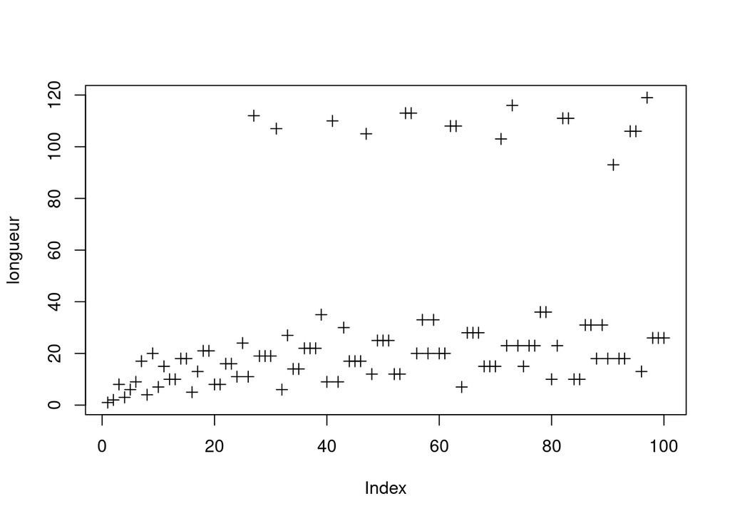

```r
plot(longueur,pch = 3)
```

### Question 3

```r
library(microbenchmark)
    longueur2=sapply(sapply(1:n,syracuse),length)

longueur2
```

```
##   [1]   1   2   8   3   6   9  17   4  20   7  15  10  10  18  18   5  13  21
##  [19]  21   8   8  16  16  11  24  11 112  19  19  19 107   6  27  14  14  22
##  [37]  22  22  35   9 110   9  30  17  17  17 105  12  25  25  25  12  12 113
##  [55] 113  20  33  20  33  20  20 108 108   7  28  28  28  15  15  15 103  23
##  [73] 116  23  15  23  23  36  36  10  23 111 111  10  10  31  31  18  31  18
##  [91]  93  18  18 106 106  13 119  26  26  26
```

```r
syracuse_loop=function(N){for(n in 1:N){
    longueur[n] <- length(syracuse(n))
}
  longueur}


syracuse_vec=function(N){

        longueur2=sapply(sapply(1:n,syracuse),length)
  longueur}


microbenchmark(loop=syracuse_loop(100),vec=syracuse_vec(100),times=10)
```

```
## Unit: milliseconds
##  expr      min       lq     mean   median       uq      max neval
##  loop 6.216220 6.385566 6.952987 6.429887 6.517884 9.638863    10
##   vec 6.398234 6.441703 7.414222 6.591729 8.774038 9.258088    10
```

```r
microbenchmark(loop=syracuse_loop(1000),vec=syracuse_vec(1000),times=10)
```

```
## Unit: milliseconds
##  expr        min         lq       mean     median         uq        max neval
##  loop 138.410921 140.205054 142.318793 142.267381 142.450550 146.727810    10
##   vec   6.412281   6.760883   7.261665   6.892196   7.002748   9.405408    10
```

La longueur maximale est :

```r
max(longueur)
```

```
## [1] 119
```

Pour trouver l’entier $n$ entre 1 et 100 générant cette longueur maximale :

```r
which.max(longueur)
```

```
## [1] 97
```

Pour représenter cette suite :

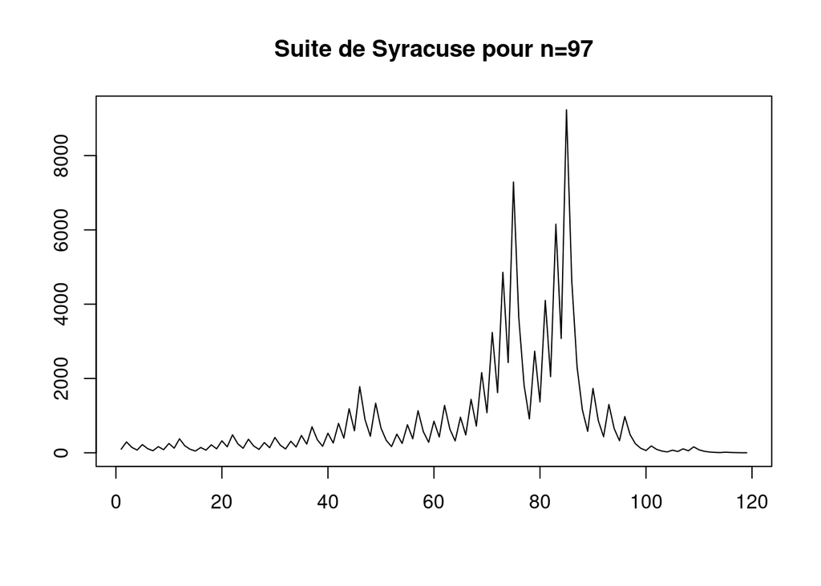

```r
syrmax <- syracuse(which.max(longueur))
plot(1:length(syrmax), syrmax, type = 'l',
    xlab = '',ylab = '', main = 'Suite de Syracuse pour n=97'
    )
```

## 3.4. Etude d’un jeu de données

```r
donnees <- read.table("snore.txt")
```

### Question 1

Le premier individu correspond normalement à la première ligne

```r
donnees[1, ]
```

```
##    V1    V2     V3     V4   V5     V6    V7
## 1 age poids taille alcool sexe ronfle tabac
```

Problème : le premier individu correspond au nom des variables. Ce n’est pas ce qu’on veut.

### Question 2

On corrige le tir en spécifiant que la première ligne du data-frame correspond au nom des variables

```r
donnees <- read.table("snore.txt",header=TRUE)
```

On verifie que le problème est réglé.

```r
donnees[1,]
```

```
##   age poids taille alcool sexe ronfle tabac
## 1  47    71    158      0    H      N     O
```

### Question 3

Comme son nom l’indique, la commande **summary** permet d’avoir un résumé du jeu de données. Noter la différence entre les variables quantitatives et qualitatives.

```r
summary(donnees)
```

```
##       age            poids            taille          alcool
##  Min.   :23.00   Min.   : 42.00   Min.   :158.0   Min.   : 0.00
##  1st Qu.:43.00   1st Qu.: 77.00   1st Qu.:166.0   1st Qu.: 0.00
##  Median :52.00   Median : 95.00   Median :186.0   Median : 2.00
##  Mean   :52.27   Mean   : 90.41   Mean   :181.1   Mean   : 2.95
##  3rd Qu.:62.25   3rd Qu.:107.00   3rd Qu.:194.0   3rd Qu.: 4.25
##  Max.   :74.00   Max.   :120.00   Max.   :208.0   Max.   :15.00
##      sexe              ronfle             tabac
##  Length:100         Length:100         Length:100
##  Class :character   Class :character   Class :character
##  Mode  :character   Mode  :character   Mode  :character
##
##
##
```

### Question 4

On commence par créer une liste de deux data-frames, appelée **decoupe**

```r
decoupe <- split(donnees,donnees$ronfle)
ls(decoupe)
```

```
## [1] "N" "O"
```

```r
class(decoupe)
```

```
## [1] "list"
```

On donne ensuite les noms voulus aux deux éléments de cette liste

```r
nonronfleur <- decoupe$N
ronfleur <- decoupe$O
```

### Question 5

On résume les deux jeux de données obtenus.

```r
summary(ronfleur)
```

```
##       age           poids            taille          alcool
##  Min.   :32.0   Min.   : 49.00   Min.   :159.0   Min.   : 0.000
##  1st Qu.:47.5   1st Qu.: 77.50   1st Qu.:166.5   1st Qu.: 1.000
##  Median :57.0   Median : 96.00   Median :187.0   Median : 4.000
##  Mean   :56.0   Mean   : 90.29   Mean   :181.4   Mean   : 4.029
##  3rd Qu.:65.5   3rd Qu.:104.50   3rd Qu.:194.0   3rd Qu.: 6.000
##  Max.   :74.0   Max.   :117.00   Max.   :198.0   Max.   :15.000
##      sexe              ronfle             tabac
##  Length:35          Length:35          Length:35
##  Class :character   Class :character   Class :character
##  Mode  :character   Mode  :character   Mode  :character
##
##
##
```

```r
summary(nonronfleur)
```

```
##       age            poids            taille        alcool
##  Min.   :23.00   Min.   : 42.00   Min.   :158   Min.   : 0.000
##  1st Qu.:41.00   1st Qu.: 77.00   1st Qu.:166   1st Qu.: 0.000
##  Median :49.00   Median : 94.00   Median :183   Median : 0.000
##  Mean   :50.26   Mean   : 90.48   Mean   :181   Mean   : 2.369
##  3rd Qu.:59.00   3rd Qu.:107.00   3rd Qu.:194   3rd Qu.: 4.000
##  Max.   :70.00   Max.   :120.00   Max.   :208   Max.   :12.000
##      sexe              ronfle             tabac
##  Length:65          Length:65          Length:65
##  Class :character   Class :character   Class :character
##  Mode  :character   Mode  :character   Mode  :character
##
##
##
```

On constate qu’en moyenne, les ronfleurs sont plus âgés et boivent plus. On note aussi que la proportion d’hommes est plus importante chez les ronfleurs que chez les non-ronfleurs.

### Question 6

Pour déterminer la proportion d’hommes parmi les personnes qui ronflent :

```r
n1 <- nrow(ronfleur)
nbhommes1 <- sum(ronfleur$sexe == "H")
nbhommes1/n1
```

```
## [1] 0.8571429
```

Pour déterminer la proportion de ronfleurs parmi les hommes

```r
nbhommes <- sum(donnees$sexe == "H")
nbhommes1/nbhommes
```

```
## [1] 0.4
```

## 3.5 Chaîne de Markov

### Question 1

```r
P=matrix(c(1/3,0,1/2,1/3,1/2,1/2,1/3,1/2,0),nrow=3)
N=50 ## longueur de la trajectoire
x=1 ## état initial
traj=c(x)
for (n in 1:N)
{
  P_x=P[x,]
  u=runif(1) ## on tire un nombre uniformément entre 0 et 1
  if (u<P_x[1]){etat=1} else if (u < (P_x[1]+P_x[2])) {etat=2} else {etat=3}
  x=etat
  traj=c(traj,etat)
}
```

### Question 2

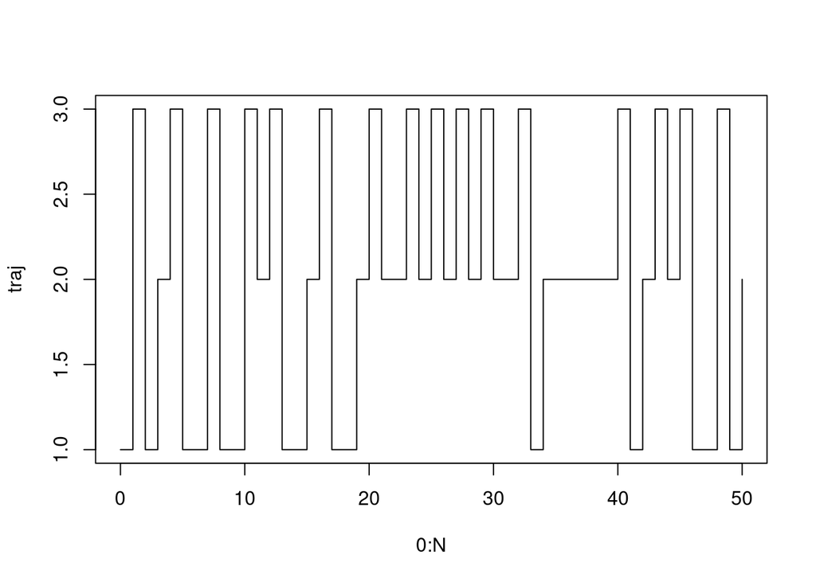

```r
plot(0:N,traj,"s")
```

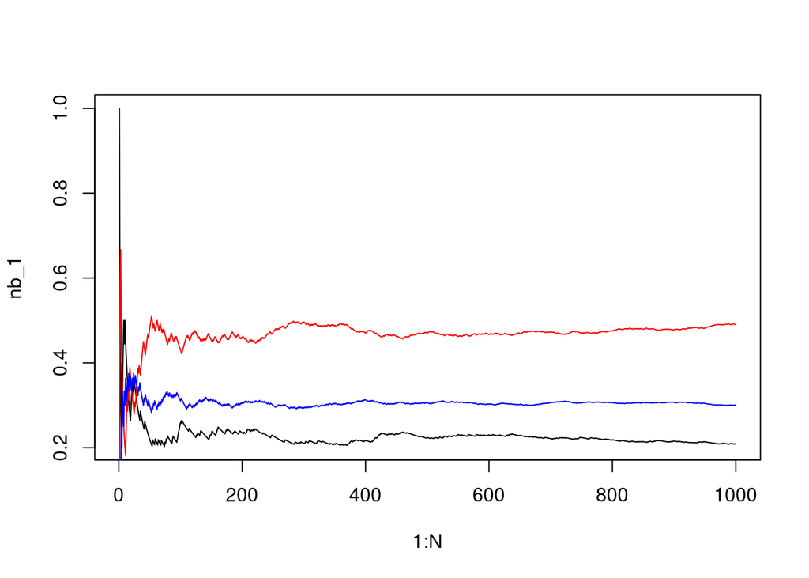

```r
N=1000 ## longueur de la trajectoire
x=1 ## état initial
traj=c(x)
for (n in 1:N)
{
  P_x=P[x,]
  u=runif(1) ## on tire un nombre uniformément entre 0 et 1
  if (u<P_x[1]){etat=1} else if (u < (P_x[1]+P_x[2])) {etat=2} else {etat=3}
  x=etat
  traj=c(traj,etat)
}

nb_1=sapply(1:N,FUN=function(T)
  {
  traj_red=traj[1:T]
  length(which(traj_red==1))/T
})

nb_2=sapply(1:N,FUN=function(T)
  {
  traj_red=traj[1:T]
  length(which(traj_red==2))/T
})

nb_3=sapply(1:N,FUN=function(T)
  {
  traj_red=traj[1:T]
  length(which(traj_red==3))/T
})


plot(1:N, nb_1,"l")
lines(1:N,nb_2,col="red")
lines(1:N,nb_3,col="blue")
```

On voit que ces trois quantités, qui correspondent au temps relatif que la chaîne passe dans chacun des 3 états, ont l’air de converger. Le théorème ergodique nous assure que sous une hypothèse d’irréductibilité (vérifiée ici), c’est bien le cas.